# Pageview-Analysis

Goal: test if the frontend had a significant impact on pageviews. Idea: use Wikipedia-pageviews on school-materials to predict Serlo-ones (and account therefore for some temporal differences) and introduce frontend as additional predictor whose influence and significance we want to calculate/test.

# Intro

We have two datasets: the variance and mean-normalised data `normalised_data` and the non-normalised original data `non_normalised`. Reading both in:

```r
#setwd("~/Desktop/Serlo/Aufrufe_Analyse")

#non_normalised <- read.csv("pageviews-not-normalized.csv",colClasses=c("Date",NA, NA))
non_normalised  <- read.csv("data/pageviews_170221.csv", colClasses=c("Date",NA, NA))
non_normalised <- as_tibble(non_normalised)

normalised_data <- non_normalised

normalised_data$serlo <- (normalised_data$serlo - mean(normalised_data$serlo))/sd(normalised_data$serlo)
normalised_data$wikipedia <- (normalised_data$wikipedia - mean(normalised_data$wikipedia))/sd(normalised_data$wikipedia)

#normalised_data <- read.csv("pageviews.csv", colClasses=c("Date",NA, NA))
#normalised_data <- as_tibble(normalised_data)


head(normalised_data)
```

```
## # A tibble: 6 x 3
##   timestamp   serlo wikipedia
##   <date>      <dbl>     <dbl>
## 1 2020-09-01 -0.589    -0.700
## 2 2020-09-02 -0.540    -0.656
## 3 2020-09-03 -0.638    -0.756
## 4 2020-09-04 -1.29     -1.45
## 5 2020-09-05 -1.51     -1.89
## 6 2020-09-06 -0.726    -1.19
```

```r
head(non_normalised)
```

```
## # A tibble: 6 x 3
##   timestamp  serlo wikipedia
##   <date>     <int>     <dbl>
## 1 2020-09-01 41282      260.
## 2 2020-09-02 42249      265.
## 3 2020-09-03 40294      255.
## 4 2020-09-04 27334      190.
## 5 2020-09-05 22974      149
## 6 2020-09-06 38553      215.
```

I introduce two new variables: the full-deployment of the frontend, starting from the 28.01.21 and the beginning of Germany-wide homeschooling on the 15.12.2020:

```r
normalised_data %<>% mutate(frontend = ifelse(timestamp >= as.Date("2021-01-28"), TRUE, FALSE))
normalised_data %<>% mutate(homeschooling = ifelse(timestamp >= as.Date("2021-01-11") | timestamp %in% seq(as.Date("2020-12-15"), by = "day", length.out = 4), TRUE, FALSE))
normalised_data %<>% drop_na()

non_normalised %<>% mutate(frontend = ifelse(timestamp >= as.Date("2021-01-28"), TRUE, FALSE))
non_normalised %<>% mutate(homeschooling = ifelse(timestamp >= as.Date("2021-01-11") | timestamp %in% seq(as.Date("2020-12-15"), by = "day", length.out = 4), TRUE, FALSE))

non_normalised %<>% drop_na()
```

Plots showing the joint variation of both page-visits (plotting the normalised values here):

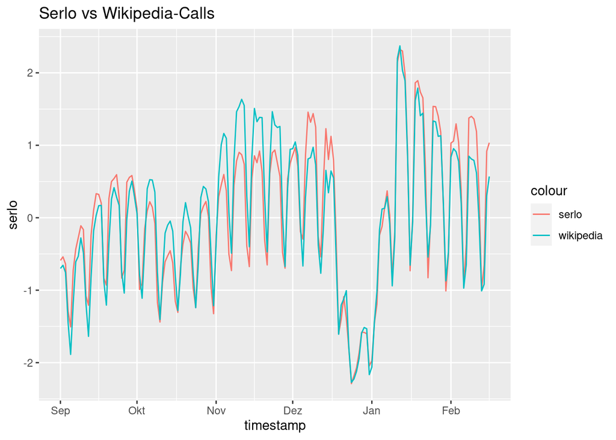

```r
normalised_data %>%
  ggplot(aes(timestamp)) +
  geom_line(aes(y=serlo, col="serlo")) +
  geom_line(aes(y=wikipedia, col="wikipedia")) +
  ggtitle("Serlo vs Wikipedia-Calls")
```

```r
ggsave("plots/serlo_vs_wikipedia_over_time.png")
```

I want to use the Wikipedia-Calls to predict the Serlo-ones. Plots of all data-points split up by homeschooling:

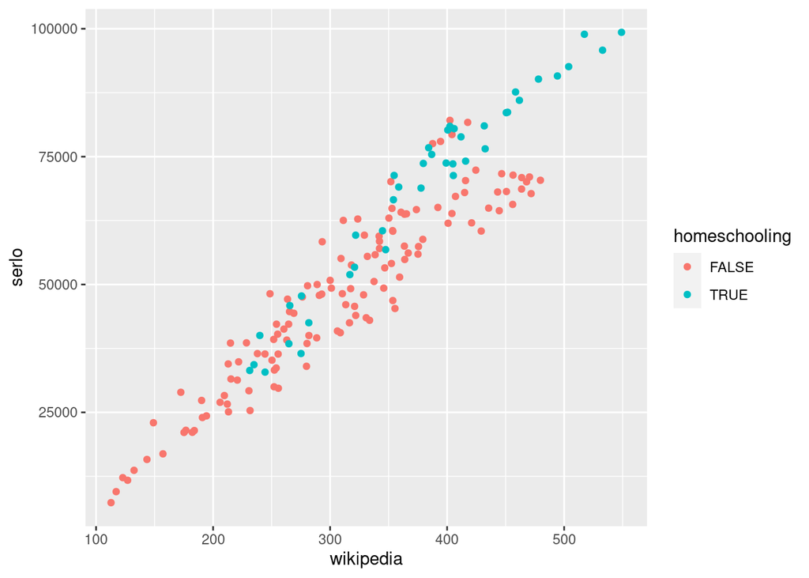

```r
non_normalised %>%
  ggplot(aes(x=wikipedia, y=serlo, col=homeschooling)) +
  geom_point()
```

Interesting is the relatively strong linearity when homeschooling is there, but the higher variance otherwise. It may be an effect of not enough datapoints or something more fundamental (possible explanation could be the especially big values during homeschooling + less datapoints for the middle):

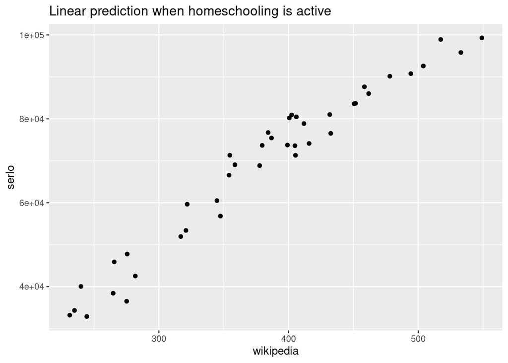

```r
non_normalised %>%
  filter(homeschooling==TRUE) %>%
  ggplot(aes(x=wikipedia, y=serlo)) +
  geom_point() +
  ggtitle("Linear prediction when homeschooling is active")
```

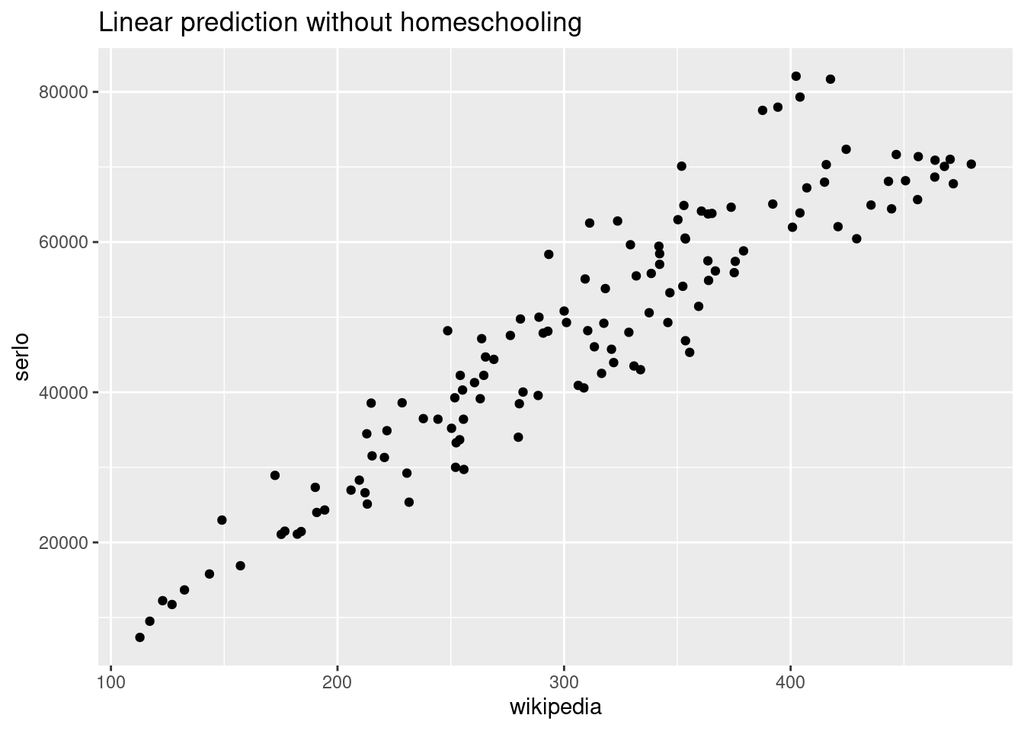

```r
non_normalised %>%
  filter(homeschooling==FALSE) %>%
  ggplot(aes(x=wikipedia, y=serlo)) +
  geom_point() +
  ggtitle("Linear prediction without homeschooling")
```

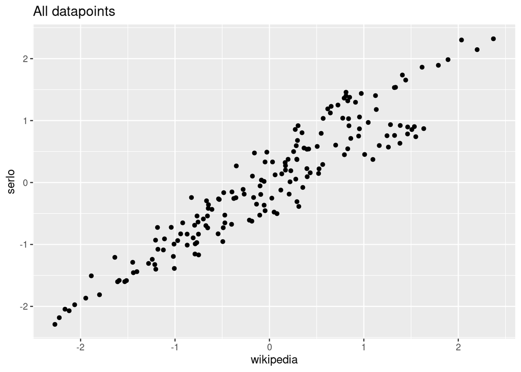

```r
normalised_data %>%
  ggplot(aes(x=wikipedia, y=serlo)) +
  geom_point() +
  ggtitle("All datapoints")
```

```r
non_normalised %>% group_by(homeschooling) %>% count(n=n())
```

```
## Storing counts in `nn`, as `n` already present in input
## ℹ Use `name = "new_name"` to pick a new name.
```

```
## # A tibble: 2 x 3
## # Groups:   homeschooling [2]
##   homeschooling     n    nn
##   <lgl>         <int> <int>
## 1 FALSE           128   128
## 2 TRUE             41    41
```

Given `homeschooling=TRUE`, it seems like we have a nearly linear trend, with still some deviations for big and small values. For the other datapoints there it more deviation in the middle/upper end of the graph –> it seems like the error-variance is depending on the predictor-values.

# Linear models

Looking at these plots we see that fitting a linear model is probably problematic, since probably the normality-assumption for the residuals does not hold. This is true:

```r
fit <- lm(serlo ~ wikipedia + homeschooling + frontend, normalised_data)
summary(fit)
```

```
##
## Call:
## lm(formula = serlo ~ wikipedia + homeschooling + frontend, data = normalised_data)
##
## Residuals:
##      Min       1Q   Median       3Q      Max
## -0.60940 -0.19736 -0.04113  0.20642  0.82208
##
## Coefficients:
##                   Estimate Std. Error t value Pr(>|t|)
## (Intercept)       -0.08815    0.02731  -3.228   0.0015 **
## wikipedia          0.89208    0.02528  35.291  < 2e-16 ***
## homeschoolingTRUE  0.35423    0.07693   4.605 8.21e-06 ***
## frontendTRUE       0.01872    0.09686   0.193   0.8470
## ---
## Signif. codes:  0 '***' 0.001 '**' 0.01 '*' 0.05 '.' 0.1 ' ' 1
##
## Residual standard error: 0.3045 on 165 degrees of freedom
## Multiple R-squared:  0.9089, Adjusted R-squared:  0.9073
## F-statistic: 548.8 on 3 and 165 DF,  p-value: < 2.2e-16
```

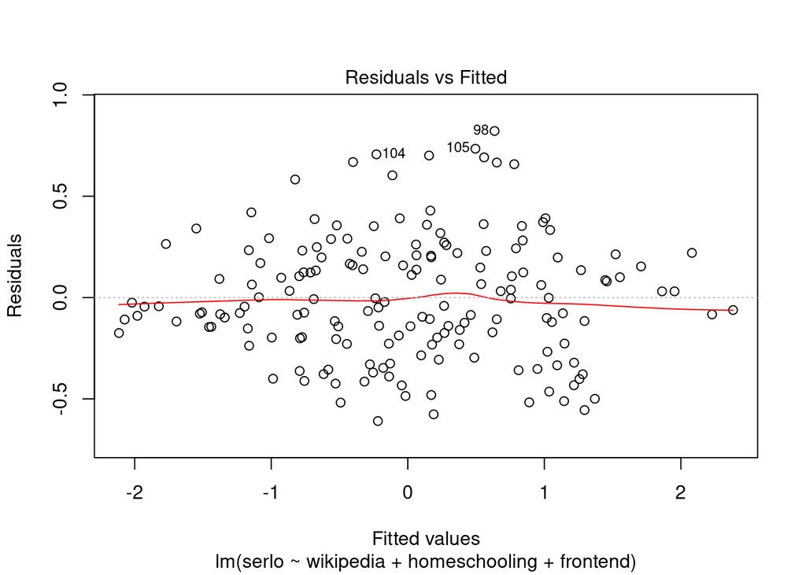

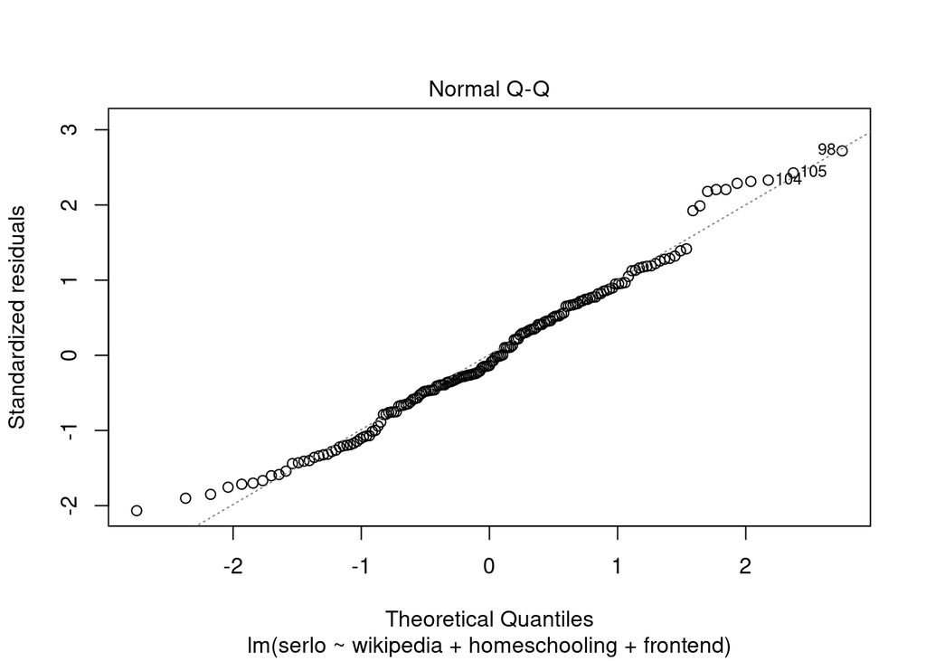

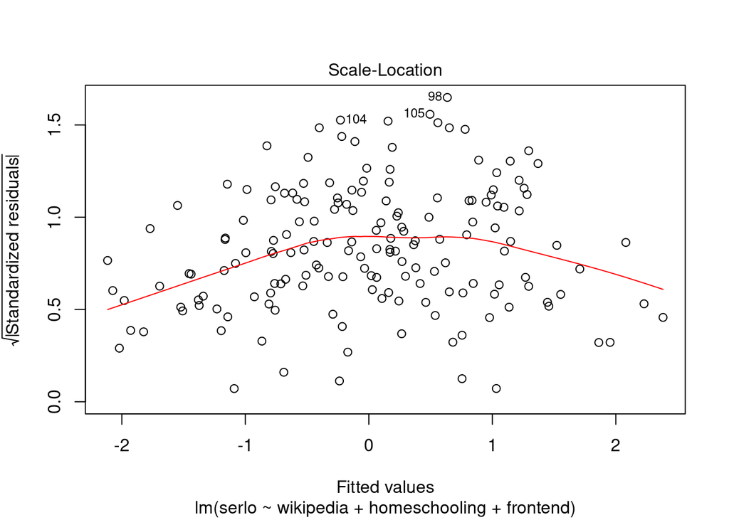

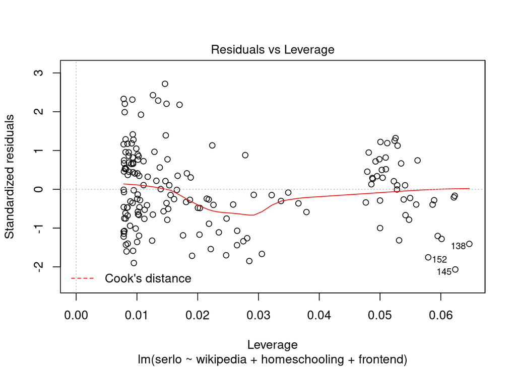

```r
plot(fit)
```

And a formal ks-test on normality of the residuals lets us to strongly reject their normality:

```r
ks.test(resid(fit), "pnorm")
```

```
##
##  One-sample Kolmogorov-Smirnov test
##
## data:  resid(fit)
## D = 0.2843, p-value = 2.729e-12
## alternative hypothesis: two-sided
```

Here I introduced `homeschooling` as additional predictor, since it seems to slightly change aboves relationship between Serlo and Wikipedia-pageviews.

We need to think of another model. Given `homeschooling=FALSE` it seems like the error-variance in a linear-model we fit, depends on the pageviews of our Wikipedia-random-variable $W$. I can try a multiplicative model:

$$S \sim W\epsilon \implies log(S) \sim log(W) + log(\epsilon) \text{ with } \epsilon \sim N(1, \sigma^2)$$

Trying a log-transformation on both-sides, but still with Gaussian Errors I get:

```r
fit_log_trafo <- lm(log(serlo) ~ log(wikipedia) + homeschooling, non_normalised)
summary(fit_log_trafo)
```

```
##
## Call:
## lm(formula = log(serlo) ~ log(wikipedia) + homeschooling, data = non_normalised)
##
## Residuals:
##      Min       1Q   Median       3Q      Max
## -0.50853 -0.08392 -0.01555  0.09478  0.31644
##
## Coefficients:
##                   Estimate Std. Error t value Pr(>|t|)
## (Intercept)        3.09980    0.18705  16.572  < 2e-16 ***
## log(wikipedia)     1.33552    0.03284  40.667  < 2e-16 ***
## homeschoolingTRUE  0.09363    0.02472   3.787 0.000213 ***
## ---
## Signif. codes:  0 '***' 0.001 '**' 0.01 '*' 0.05 '.' 0.1 ' ' 1
##
## Residual standard error: 0.1313 on 166 degrees of freedom
## Multiple R-squared:  0.9212, Adjusted R-squared:  0.9202
## F-statistic: 969.6 on 2 and 166 DF,  p-value: < 2.2e-16
```

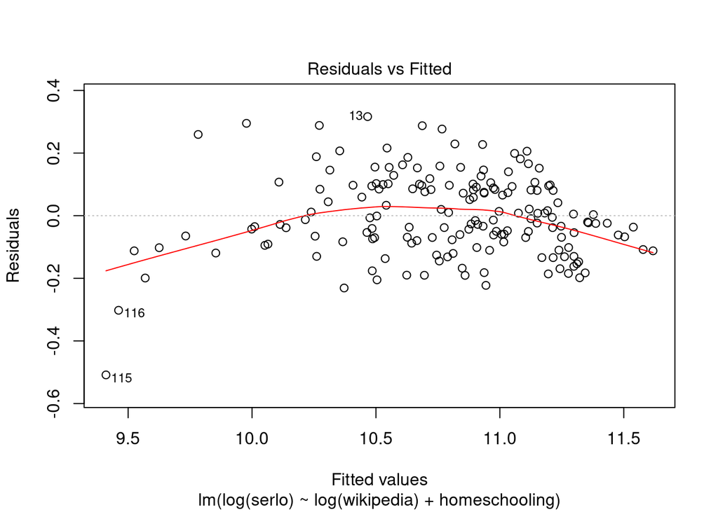

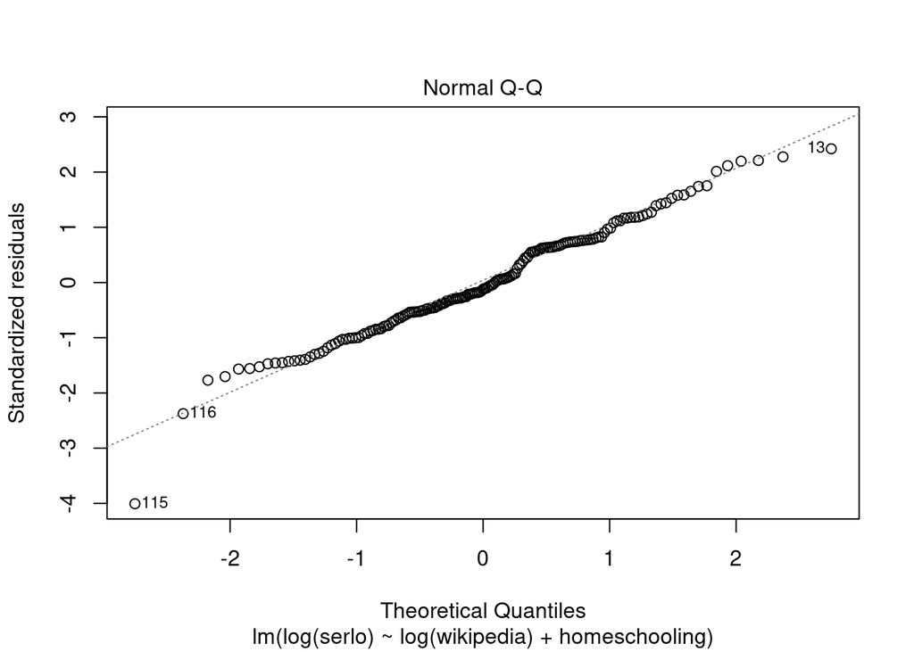

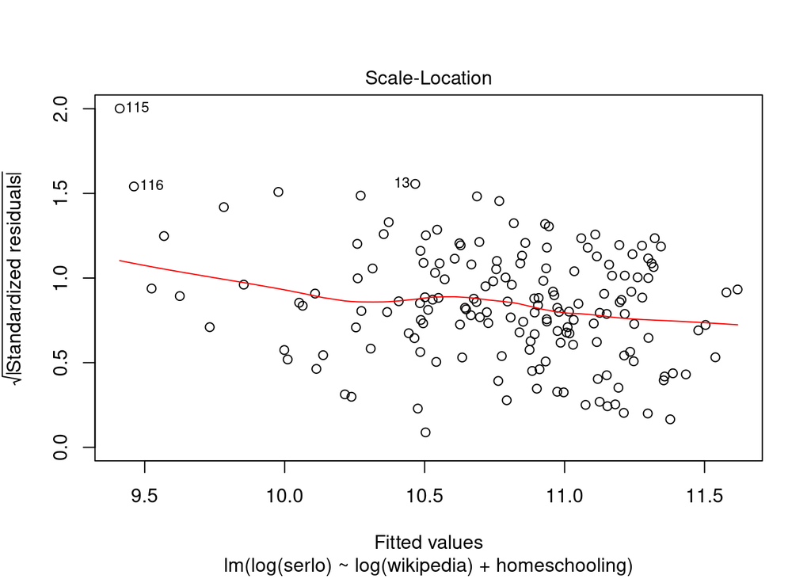

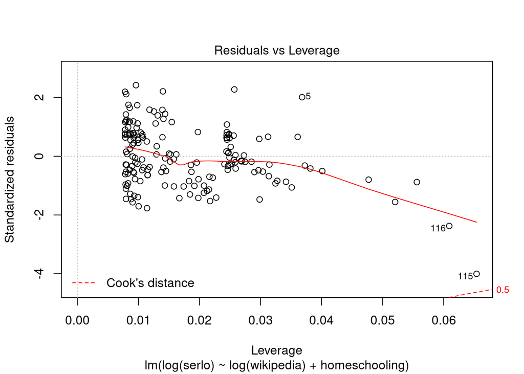

```r
plot(fit_log_trafo)
```

And without homeschooling-predictor:

```r
fit_log_trafo_wout_homeschooling <- lm(log(serlo) ~ log(wikipedia), non_normalised)
summary(fit_log_trafo_wout_homeschooling)
```

```
##
## Call:
## lm(formula = log(serlo) ~ log(wikipedia), data = non_normalised)
##
## Residuals:
##      Min       1Q   Median       3Q      Max
## -0.49303 -0.09375  0.00710  0.09705  0.30217
##
## Coefficients:
##                Estimate Std. Error t value Pr(>|t|)
## (Intercept)     2.90630    0.18699   15.54   <2e-16 ***
## log(wikipedia)  1.37319    0.03252   42.22   <2e-16 ***
## ---
## Signif. codes:  0 '***' 0.001 '**' 0.01 '*' 0.05 '.' 0.1 ' ' 1
##
## Residual standard error: 0.1364 on 167 degrees of freedom
## Multiple R-squared:  0.9143, Adjusted R-squared:  0.9138
## F-statistic:  1783 on 1 and 167 DF,  p-value: < 2.2e-16
```

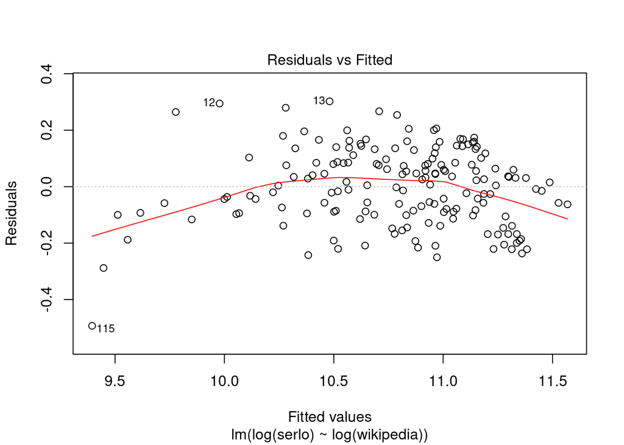

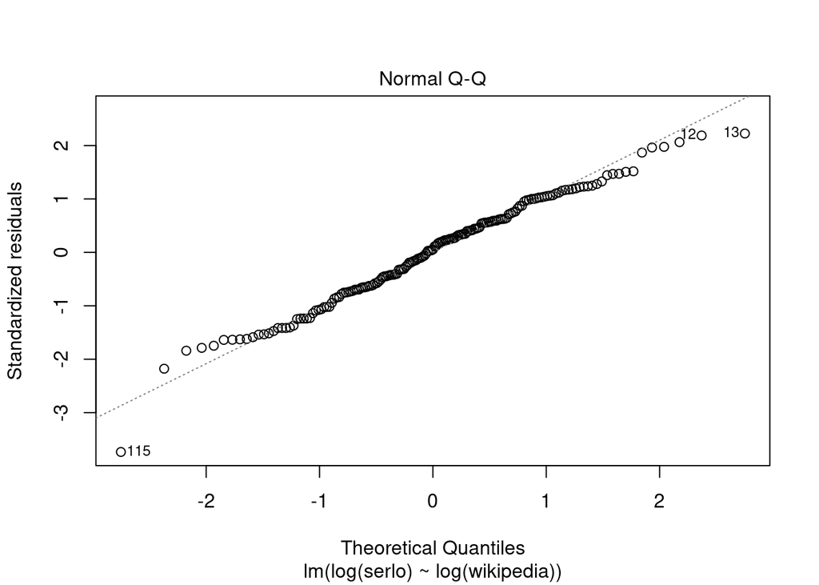

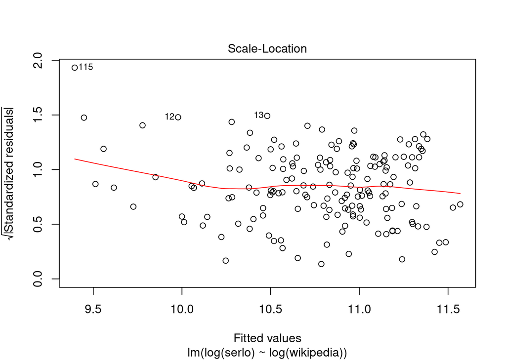

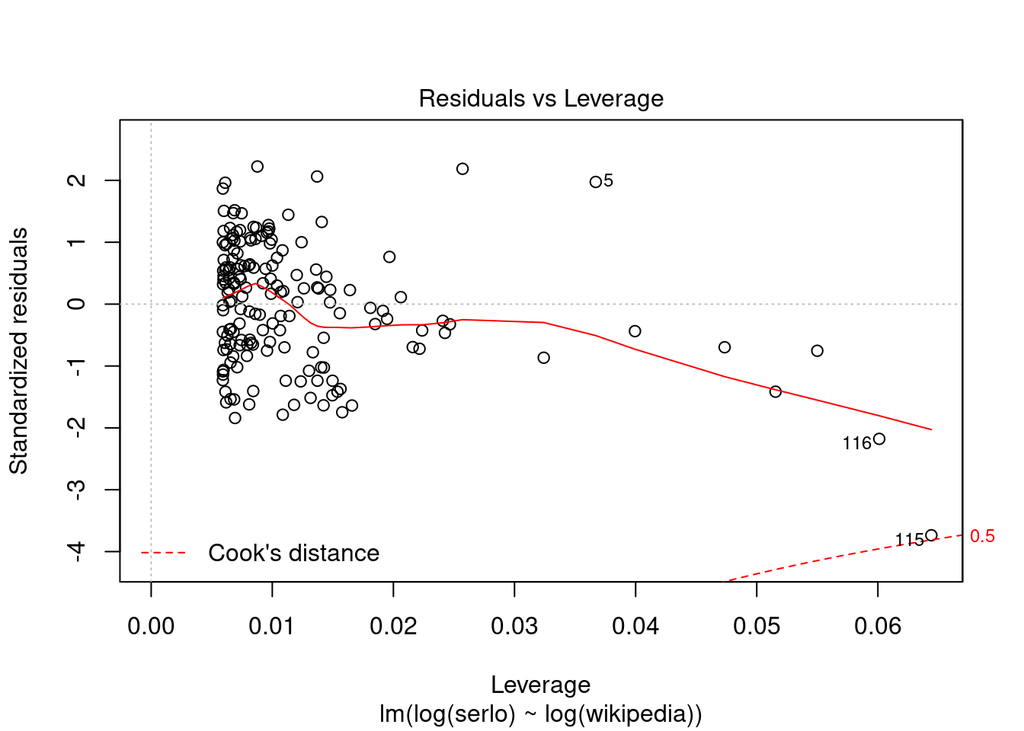

```r
plot(fit_log_trafo_wout_homeschooling)
```

This already seems better (quite good even), without it being it. Now I can try a the above model with log-normal-errors.

A bit googling around I found this thread https://stats.stackexchange.com/questions/47840/linear-model-with-log-transformed-response-vs-generalized-linear-model-with-log) and the associated Paper. It seems to be in general better to fit a glm then with Gaussian family and log as link, than a linear model with lognormal-error. Doing that gives (first only looking at the non-homeschooling-value):

```r
hs_false <- non_normalised %>% filter(homeschooling==FALSE)

glm_log_Gaussian_hs_false <- glm(serlo ~ wikipedia , family=gaussian(link="log"), hs_false)
summary(glm_log_Gaussian_hs_false)
```

```
##
## Call:
## glm(formula = serlo ~ wikipedia, family = gaussian(link = "log"),
##     data = hs_false)
##
## Deviance Residuals:
##      Min        1Q    Median        3Q       Max
## -15980.5   -6320.9    -600.4    4919.5   18489.8
##
## Coefficients:
##              Estimate Std. Error t value Pr(>|t|)
## (Intercept) 9.6668819  0.0613054  157.68   <2e-16 ***
## wikipedia   0.0034630  0.0001659   20.88   <2e-16 ***
## ---
## Signif. codes:  0 '***' 0.001 '**' 0.01 '*' 0.05 '.' 0.1 ' ' 1
##
## (Dispersion parameter for gaussian family taken to be 59129443)
##
##     Null deviance: 3.8480e+10  on 127  degrees of freedom
## Residual deviance: 7.4503e+09  on 126  degrees of freedom
## AIC: 2657.8
##
## Number of Fisher Scoring iterations: 6
```

A small plot:

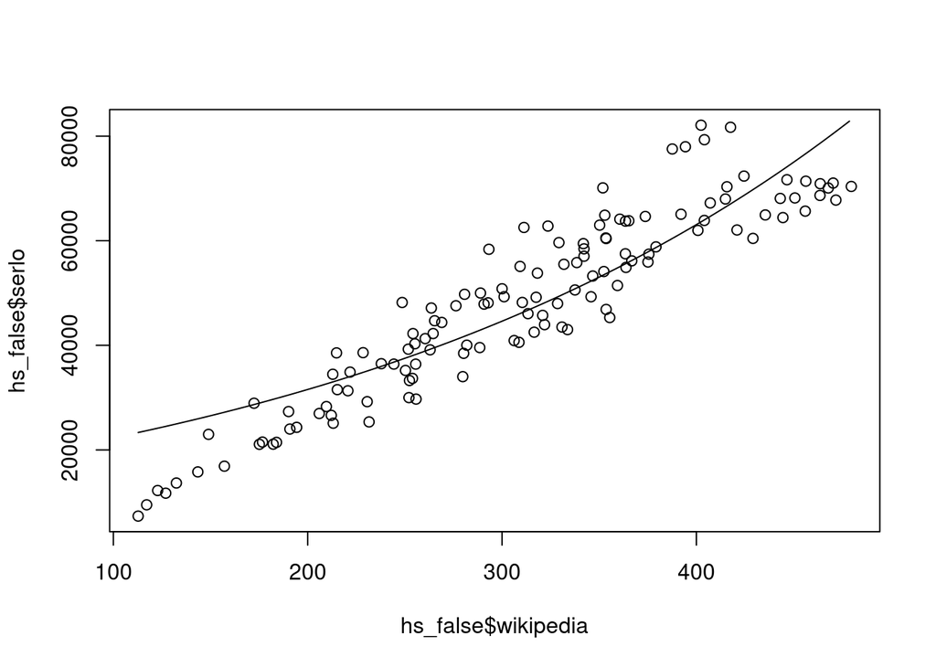

```r
wikipedia_vals <- seq(min(hs_false$wikipedia), max(hs_false$wikipedia), 1)
y_vals <- predict(glm_log_Gaussian_hs_false, list(wikipedia = wikipedia_vals), type="response")

plot(hs_false$wikipedia, hs_false$serlo)
lines(wikipedia_vals, y_vals)
```

I need to read into sanity-checks for glms, but it seems quite okay at first glance. This could be a model we could expand on. Now dropping the `homeschooling=FALSE`-condition and including as additional predictor in this glm

```r
glm_log_Gaussian <- glm(serlo ~ wikipedia +homeschooling , family=gaussian(link="log"), non_normalised)
summary(glm_log_Gaussian)
```

```
##
## Call:
## glm(formula = serlo ~ wikipedia + homeschooling, family = gaussian(link = "log"),
##     data = non_normalised)
##
## Deviance Residuals:
##      Min        1Q    Median        3Q       Max
## -17002.3   -5810.7    -408.5    4489.1   18971.8
##
## Coefficients:
##                   Estimate Std. Error t value Pr(>|t|)
## (Intercept)       9.729403   0.046971 207.135  < 2e-16 ***
## wikipedia         0.003289   0.000126  26.110  < 2e-16 ***
## homeschoolingTRUE 0.115804   0.022579   5.129 8.05e-07 ***
## ---
## Signif. codes:  0 '***' 0.001 '**' 0.01 '*' 0.05 '.' 0.1 ' ' 1
##
## (Dispersion parameter for gaussian family taken to be 55492376)
##
##     Null deviance: 6.6828e+10  on 168  degrees of freedom
## Residual deviance: 9.2117e+09  on 166  degrees of freedom
## AIC: 3498.1
##
## Number of Fisher Scoring iterations: 6
```

This is also okay, but doesn’t add much. We could now try to expand on this model or use the empirical finding of a stronger linear relationship between Serlo and Wikipedia, given `homeschooling=TRUE`, so fit a piecewise-model:

$$S = \begin{cases}
\alpha W + \beta + \epsilon & homeschooling = TRUE \\
\gamma W\epsilon & homeschooling = FALSE
\end{cases}$$

The influence on homeschooling on the values is something we need to research on more. Just for illustration: linear model given `homeschooling=TRUE`:

```r
hs_true <- non_normalised %>% filter(homeschooling==TRUE)
fit_hs_true <- lm(serlo ~ wikipedia, hs_true)
summary(fit_hs_true)
```

```
##
## Call:
## lm(formula = serlo ~ wikipedia, data = hs_true)
##
## Residuals:
##     Min      1Q  Median      3Q     Max
## -9120.4 -2982.3  -450.7  3143.7  8185.1
##
## Coefficients:
##               Estimate Std. Error t value Pr(>|t|)
## (Intercept) -14950.661   3116.065  -4.798 2.36e-05 ***
## wikipedia      220.154      8.007  27.494  < 2e-16 ***
## ---
## Signif. codes:  0 '***' 0.001 '**' 0.01 '*' 0.05 '.' 0.1 ' ' 1
##
## Residual standard error: 4362 on 39 degrees of freedom
## Multiple R-squared:  0.9509, Adjusted R-squared:  0.9497
## F-statistic: 755.9 on 1 and 39 DF,  p-value: < 2.2e-16
```

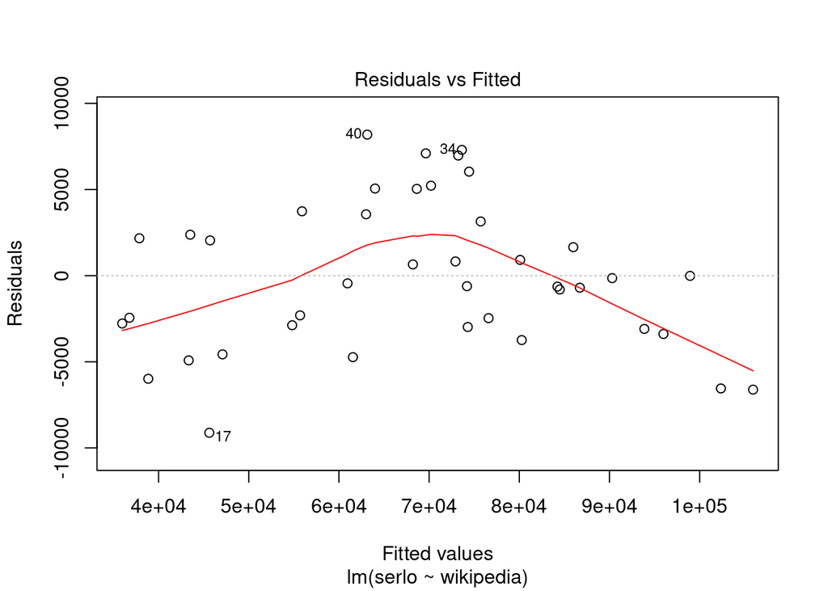

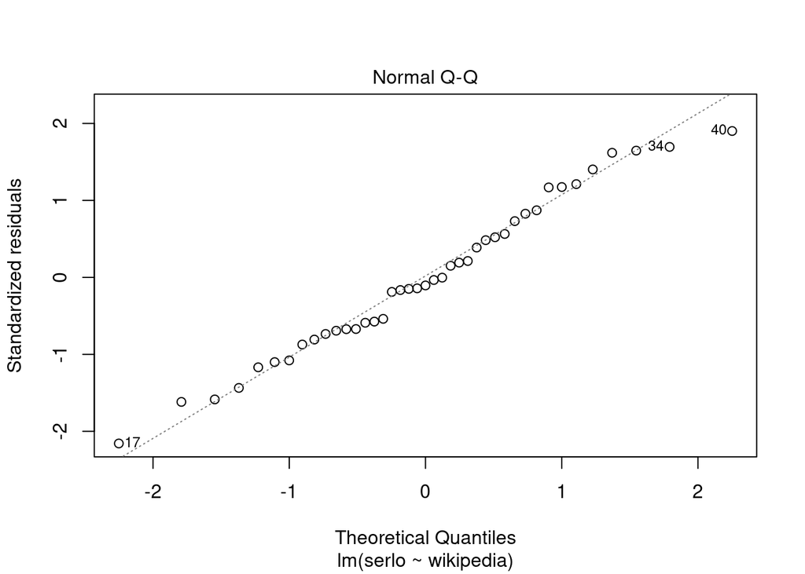

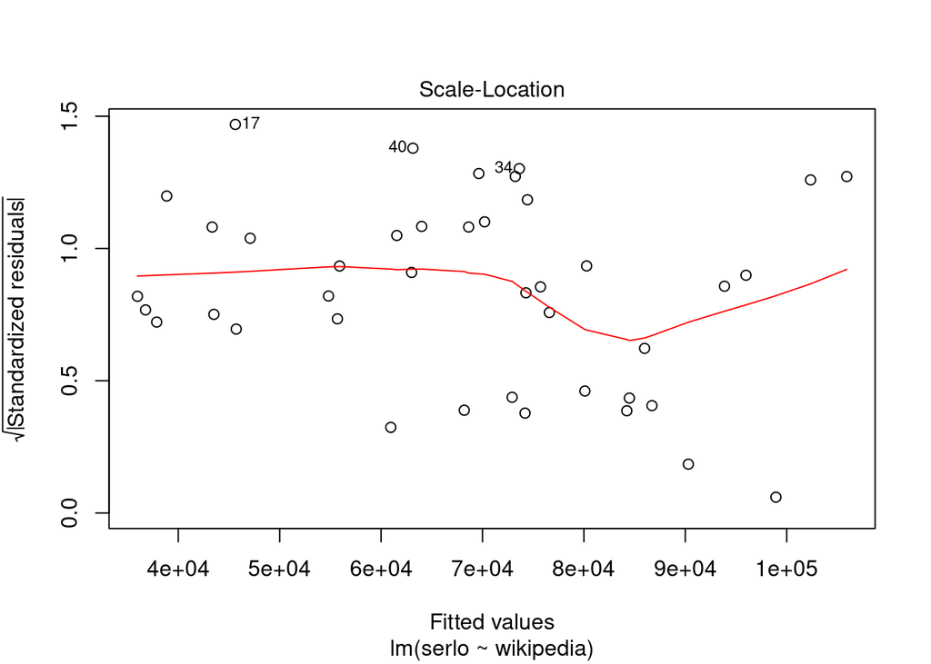

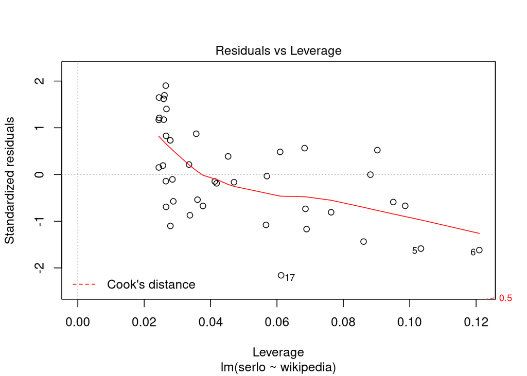

```r
plot(fit_hs_true)
```

And values vs the line:

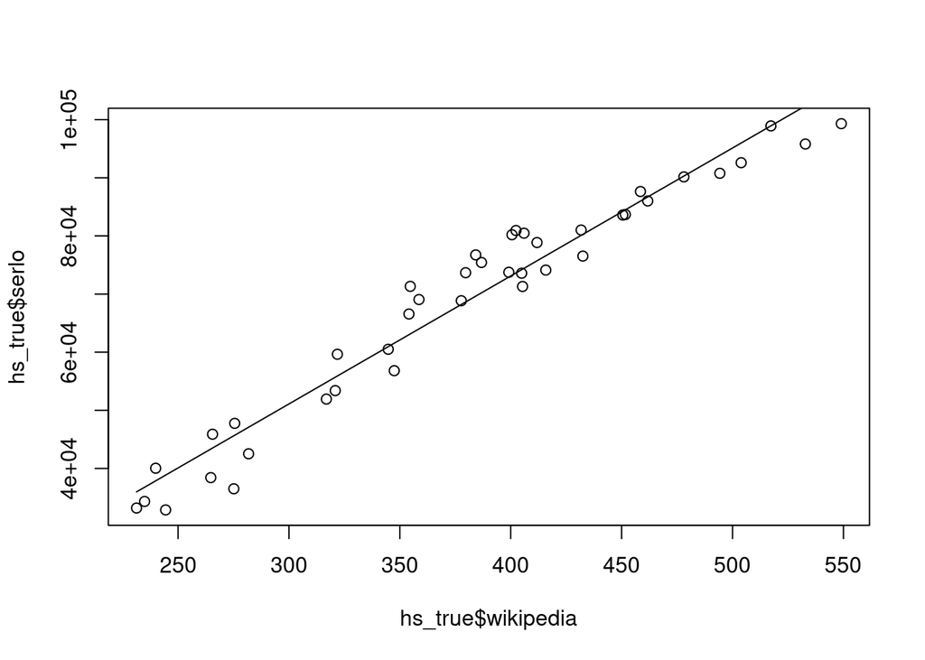

```r
plot(hs_true$wikipedia, hs_true$serlo)
lines(hs_true$wikipedia, predict(fit_hs_true))
```

# GAM

Overall we see that a linear model is not really appropriate and also the glm has a very high deviance. I now try a non-parametric-method with a gam, meaning I fit a model:

$$\mathbb E[S~|~\mathbf x] \equiv \alpha + \sum_{j = 1}^p f_j(x_j),$$
with our predictors $\mathbf x$ as splines or linear inputs. Having homeschooling as additive input and using a spline for wikipedia I get:

```r
library(gam)
```

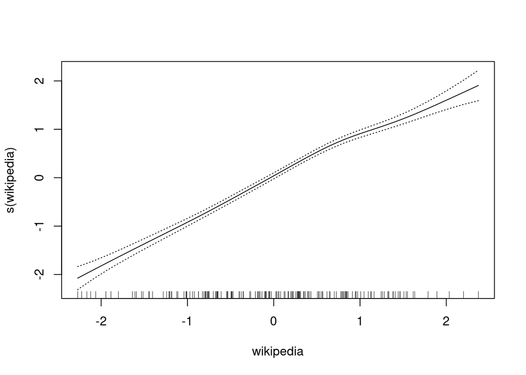

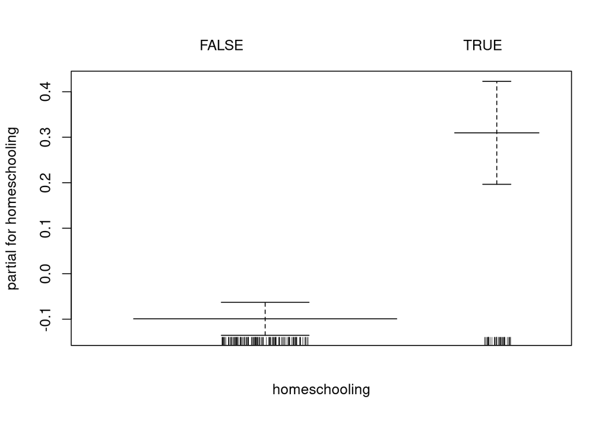

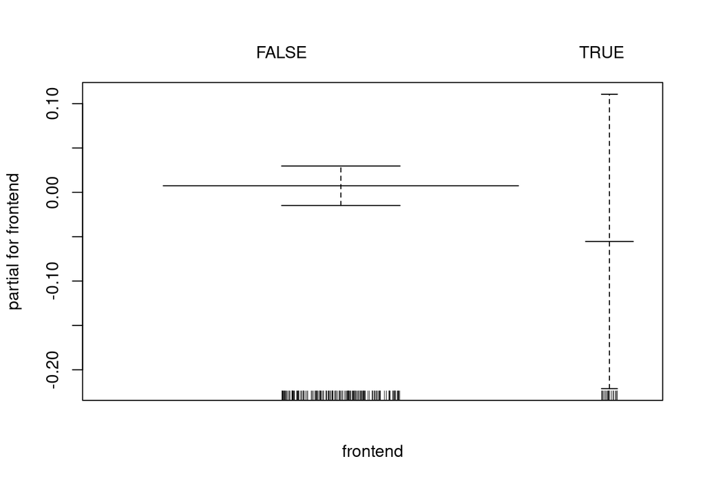

```r
normalised_gam <- gam(serlo ~ s(wikipedia) + homeschooling + frontend, data = normalised_data)

plot(normalised_gam, se = TRUE)
```

```r
summary(normalised_gam)
```

```
##
## Call: gam(formula = serlo ~ s(wikipedia) + homeschooling + frontend,
##     data = normalised_data)
## Deviance Residuals:
##     Min      1Q  Median      3Q     Max
## -0.6519 -0.2076 -0.0209  0.1769  0.7647
##
## (Dispersion Parameter for gaussian family taken to be 0.0875)
##
##     Null Deviance: 168 on 168 degrees of freedom
## Residual Deviance: 14.1728 on 161.9998 degrees of freedom
## AIC: 76.7228
##
## Number of Local Scoring Iterations: NA
##
## Anova for Parametric Effects
##                Df  Sum Sq Mean Sq   F value    Pr(>F)
## s(wikipedia)    1 149.009 149.009 1703.2240 < 2.2e-16 ***
## homeschooling   1   3.931   3.931   44.9331 3.218e-10 ***
## frontend        1   0.039   0.039    0.4451    0.5056
## Residuals     162  14.173   0.087
## ---
## Signif. codes:  0 '***' 0.001 '**' 0.01 '*' 0.05 '.' 0.1 ' ' 1
##
## Anova for Nonparametric Effects
##               Npar Df Npar F    Pr(F)
## (Intercept)
## s(wikipedia)        3  4.303 0.005966 **
## homeschooling
## frontend
## ---
## Signif. codes:  0 '***' 0.001 '**' 0.01 '*' 0.05 '.' 0.1 ' ' 1
```

This seems to fit really well. We see from the ANOVA for nonparametric effects, that there is slight evidence for rejecting $H_0$ that the Wikipedia-contribution is linear $f_W$, what we also saw above and making these approaches slightly problematic. We also see that frontend has no significant effect, whilst homeschooling and Wikipedia have a big one (with still Wikipedia dominating everything and homeschooling providing a slight adjustment on the level). One interpretation for this effect is that teachers are more likely to recommend Serlo in homeschooling that Wikipedia, shifting everything slightly

–> This model is really interesting and could give us a lot of info. I think we can now iterate on that and add predictors/expand.

# Model Comparison

Now we can compare the models. We have already seen above that the GAM-model does best when it comes to interpretation, since the assumptions of the linear models are slightly flawed and the GLM has really high deviance. But what about predictive power?

I do a 100 splits in training and test-data and and calculate the mean l1-error over those. For benchmarking-purposes I also include fitting a randomForest, which I did not include above, due to the difficult interpretability of it. I get:

```r
library(randomForest)
n <- nrow(non_normalised)
train_size <- round(2/3 * n)
folds <- 100

gam_error <- numeric(folds)
glm_error <- numeric(folds)
log_trafo_error <- numeric(folds)
linear_error <- numeric(folds)
rndforest_error <- numeric(folds)

for(i in 1:folds){
  if(i%%10 == 0) cat("Calculating fold ", i, "\n")
  train_points <- sample(n, train_size)
  train_set <- non_normalised[train_points, ]
  test_set <- non_normalised[-train_points, ]

  gam_model <- gam(serlo ~ s(wikipedia) + homeschooling + frontend, data = train_set)
  gam_error[i] <- mean(abs(predict(gam_model, test_set) - test_set$serlo))

  glm_log_Gaussian_model <- glm(serlo ~ wikipedia +homeschooling , family=gaussian(link="log"), data = train_set)
  glm_error[i] <- mean(abs(predict(glm_log_Gaussian_model, test_set) - test_set$serlo))

  log_trafo_model <- lm(log(serlo) ~ log(wikipedia) + homeschooling, data = train_set)
  log_trafo_error[i] <- mean(abs(predict(log_trafo_model, test_set) - test_set$serlo))

  linear_model <- lm(serlo ~ wikipedia + homeschooling + frontend, data = train_set)
  linear_error[i] <- mean(abs(predict(linear_model, test_set) - test_set$serlo))

  rndforest_model <- randomForest(serlo ~ wikipedia + homeschooling + frontend, data = train_set)
  rndforest_error[i] <- mean(abs(predict(rndforest_model, test_set) - test_set$serlo))

}
```

```
## Calculating fold  10
## Calculating fold  20
## Calculating fold  30
## Calculating fold  40
## Calculating fold  50
## Calculating fold  60
## Calculating fold  70
## Calculating fold  80
## Calculating fold  90
## Calculating fold  100
```

```r
mean_errors <- data.frame(names=c("GAM", "GLM", "Linear with log-trafo", "Linear model", "Random Forest"), mean_error_value=c(mean(gam_error), mean(glm_error), mean(log_trafo_error), mean(linear_error), mean(rndforest_error)))

print("Comparing the models on 100 folds of the training data and l1-error we get the following order:")
```

```
## [1] "Comparing the models on 100 folds of the training data and l1-error we get the following order:"
```

```r
print(mean_errors[order(mean_errors$mean_error_value),])
```

```
##                   names mean_error_value
## 1                   GAM         4941.039
## 4          Linear model         5003.395
## 5         Random Forest         8522.542
## 2                   GLM        53242.960
## 3 Linear with log-trafo        53242.999
```

So we see that the GAM-model achieves also the best performance (in all tests that I ran and even higher than the randomForest which is astonishing), besides being the one with the highest interpretability, quickly followed by the linear model, which seems to be a good predictor and approximation to the GAM, but whose assumptions are flawed as we saw above, and far before the GLM and linear model with log-trafo. More data will show, if this is also the case in future.

Other notes:

- Homeschooling absorbes quite a lot of the frontend effects so far in the flawed linear model and in the gam
- Under the condition of homeschooling we seems to have a linear trend (exception big and small values) –> why is that? Can we work with that?
- Including a homeschooling-wikipedia-interaction is really interesting:

```r
summary(lm(serlo ~ wikipedia*homeschooling + frontend, normalised_data))
```

```
##
## Call:
## lm(formula = serlo ~ wikipedia * homeschooling + frontend, data = normalised_data)
##
## Residuals:
##     Min      1Q  Median      3Q     Max
## -0.5550 -0.2062 -0.0398  0.1913  0.8647
##
## Coefficients:
##                             Estimate Std. Error t value Pr(>|t|)
## (Intercept)                 -0.09598    0.02648  -3.624 0.000386 ***
## wikipedia                    0.84919    0.02723  31.184  < 2e-16 ***
## homeschoolingTRUE            0.19952    0.08609   2.318 0.021703 *
## frontendTRUE                 0.14557    0.10014   1.454 0.147968
## wikipedia:homeschoolingTRUE  0.21954    0.06161   3.563 0.000480 ***
## ---
## Signif. codes:  0 '***' 0.001 '**' 0.01 '*' 0.05 '.' 0.1 ' ' 1
##
## Residual standard error: 0.2943 on 164 degrees of freedom
## Multiple R-squared:  0.9155, Adjusted R-squared:  0.9134
## F-statistic:   444 on 4 and 164 DF,  p-value: < 2.2e-16
```

The interaction is quite strong and significant. Of course the $R^2$ is higher (more predictors), but also the AIC is way lower:

```r
cat("AIC without interaction: ", AIC(fit))
```

```
## AIC without interaction:  83.68058
```

```r
cat("AIC with interaction: ", AIC(lm(serlo ~ wikipedia*homeschooling + frontend, normalised_data)))
```

```
## AIC with interaction:  73.07716
```

Is it useful to integrate the interaction? What would be an interpretation and isn’t it faulty? It seems a bit like data dredging to find some significant interaction, but maybe there is a real interpretation (is there, since homeschooling only has two levels this amounts to $\alpha W + \beta I_{hs} W + \gamma I_{hs}$, meaning that homeschooling does not only change the level (like a new mean-term, but also the influence of wikipedia –> maybe this is right: teachers get pupils onto serlo) .

- We could experiment with different glms –> Poisson-regression
- The influence of frontend is not a step-function, but rises linearly or exponentially over time. Model like $S_t = \alpha W_t + \beta e^t I_{f} + \dots$. –> exponential weighting problematic, but sigmoid-weighting, or relu?